# Projekt2

Karol Kita

2023-01-21

### **1) Wstęp**

Celem projektu jest wykorzystanie metod uczenia maszynowego w prognozowaniu raka płuc na podstawie informacji o występowaniu u pacjeta dolegliwości takich jak: duszności, alergie czy problemy z oddychaniem. W projekcie zostanie zastosowana metoda k najbliższych sąsiadów oraz ważona metoda k najbliższych sąsiadów. W predykcji zostaną wykorzystane dane lung_caner.csv pochodzące ze strony Kaggle.

### **2) Opis oraz wstępna analiza danych**

Wykorzystany zbiór danych posiada 309 obserwacji oraz 16 kolumn zmiennych. Zmienne występujące w zbiorze:

- GENDER - płeć
- AGE - wiek
- SMOKING - palący
- YELLOW_FINGERS - żółte palce
- ANXIETY - niepokój
- PEER_PRESSURE - presja rówiesników
- CHRONIC DISEASE - choroby przewlekłe
- FATIGUE - zmęczenie
- ALLERGY - alergia
- WHEEZING - świszczący oddech
- ALCOHOL CONSUMING - spożywanie alkoholu
- COUGHING - kaszel
- SHORTNESS OF BREATH - duszność
- SWALLOWING DIFFICULTY - problemy z połykaniem
- CHEST PAIN - ból w klatce piersiowej
- LUNG_CANCER - rak płuc

Zmienna GENDER posiada wartości “F”/“M” oznaczające kobietę/mężczyznę, zmienna AGE posiada wartości całkowite oznaczające wiek pacjenta. Ostatnia zmienna LUNG_CANCER zawiera informacje na temat występowania raka płuc u danej osoby. Wartościami występującymi w pozostałych zmiennych są “1” oznaczające “NIE” oraz “2” oznaczające “TAK”, które mówią występowaniu poszczególnej dolegliwości u pacjęta.

| GENDER | AGE | SMOKING | YELLOW_FINGERS | ANXIETY | PEER_PRESSURE | CHRONIC.DISEASE | FATIGUE | ALLERGY | WHEEZING | ALCOHOL.CONSUMING | COUGHING | SHORTNESS.OF.BREATH | SWALLOWING.DIFFICULTY | CHEST.PAIN | LUNG_CANCER |
| --- | --- | --- | --- | --- | --- | --- | --- | --- | --- | --- | --- | --- | --- | --- | --- |
| M | 69 | 1 | 2 | 2 | 1 | 1 | 2 | 1 | 2 | 2 | 2 | 2 | 2 | 2 | YES |
| M | 74 | 2 | 1 | 1 | 1 | 2 | 2 | 2 | 1 | 1 | 1 | 2 | 2 | 2 | YES |
| F | 59 | 1 | 1 | 1 | 2 | 1 | 2 | 1 | 2 | 1 | 2 | 2 | 1 | 2 | NO |
| M | 63 | 2 | 2 | 2 | 1 | 1 | 1 | 1 | 1 | 2 | 1 | 1 | 2 | 2 | NO |
| F | 63 | 1 | 2 | 1 | 1 | 1 | 1 | 1 | 2 | 1 | 2 | 2 | 1 | 1 | NO |
| F | 75 | 1 | 2 | 1 | 1 | 2 | 2 | 2 | 2 | 1 | 2 | 2 | 1 | 1 | YES |
| M | 52 | 2 | 1 | 1 | 1 | 1 | 2 | 1 | 2 | 2 | 2 | 2 | 1 | 2 | YES |
| F | 51 | 2 | 2 | 2 | 2 | 1 | 2 | 2 | 1 | 1 | 1 | 2 | 2 | 1 | YES |
| F | 68 | 2 | 1 | 2 | 1 | 1 | 2 | 1 | 1 | 1 | 1 | 1 | 1 | 1 | NO |
| M | 53 | 2 | 2 | 2 | 2 | 2 | 1 | 2 | 1 | 2 | 1 | 1 | 2 | 2 | YES |
| F | 61 | 2 | 2 | 2 | 2 | 2 | 2 | 1 | 2 | 1 | 2 | 2 | 2 | 1 | YES |
| M | 72 | 1 | 1 | 1 | 1 | 2 | 2 | 2 | 2 | 2 | 2 | 2 | 1 | 2 | YES |
| F | 60 | 2 | 1 | 1 | 1 | 1 | 2 | 1 | 1 | 1 | 1 | 2 | 1 | 1 | NO |
| M | 58 | 2 | 1 | 1 | 1 | 1 | 2 | 2 | 2 | 2 | 2 | 2 | 1 | 2 | YES |
| M | 69 | 2 | 1 | 1 | 1 | 1 | 1 | 2 | 2 | 2 | 2 | 1 | 1 | 2 | NO |
| F | 48 | 1 | 2 | 2 | 2 | 2 | 2 | 2 | 2 | 1 | 2 | 2 | 2 | 1 | YES |
| M | 75 | 2 | 1 | 1 | 1 | 2 | 1 | 2 | 2 | 2 | 2 | 2 | 1 | 2 | YES |
| M | 57 | 2 | 2 | 2 | 2 | 2 | 1 | 1 | 1 | 2 | 1 | 1 | 2 | 2 | YES |
| F | 68 | 2 | 2 | 2 | 2 | 2 | 2 | 1 | 1 | 1 | 2 | 2 | 1 | 1 | YES |
| F | 61 | 1 | 1 | 1 | 1 | 2 | 2 | 1 | 1 | 1 | 1 | 2 | 1 | 1 | NO |
| F | 44 | 2 | 2 | 2 | 2 | 2 | 2 | 1 | 1 | 1 | 1 | 2 | 2 | 1 | YES |
| F | 64 | 1 | 2 | 2 | 2 | 1 | 1 | 2 | 2 | 1 | 2 | 1 | 2 | 1 | YES |
| F | 21 | 2 | 1 | 1 | 1 | 2 | 2 | 2 | 1 | 1 | 1 | 2 | 1 | 1 | NO |
| M | 60 | 2 | 1 | 1 | 1 | 1 | 2 | 2 | 2 | 2 | 2 | 2 | 1 | 2 | YES |
| M | 72 | 2 | 2 | 2 | 2 | 2 | 1 | 2 | 2 | 2 | 2 | 1 | 2 | 2 | YES |
| M | 65 | 1 | 2 | 2 | 1 | 1 | 2 | 1 | 2 | 2 | 2 | 2 | 2 | 2 | YES |
| F | 61 | 2 | 2 | 2 | 1 | 1 | 2 | 2 | 1 | 2 | 1 | 2 | 2 | 2 | YES |
| M | 69 | 1 | 1 | 1 | 2 | 1 | 2 | 1 | 2 | 1 | 2 | 2 | 1 | 2 | NO |
| F | 53 | 2 | 2 | 2 | 1 | 2 | 1 | 1 | 2 | 2 | 1 | 2 | 2 | 2 | YES |
| M | 55 | 1 | 2 | 1 | 1 | 1 | 2 | 1 | 2 | 2 | 2 | 2 | 1 | 1 | NO |

[output cut: 279 more lines]

**Podstawowe statystyki**

AGE

```
##    Min. 1st Qu.  Median    Mean 3rd Qu.    Max.
##    21.0    57.0    62.0    62.7    69.0    87.0
```

GENDER

```
##   F   M
## 147 162
```

SMOKING

```
##   1   2
## 135 174
```

YELLOW_FINGERS

```
##   1   2
## 133 176
```

ANXIETY

```
##   1   2
## 155 154
```

PEER_PRESSURE

```
##   1   2
## 154 155
```

CHRONIC.DISEASE

```
##   1   2
## 153 156
```

FATIGUE

```
##   1   2
## 101 208
```

ALLERGY

```
##   1   2
## 137 172
```

WHEEZING

```
##   1   2
## 137 172
```

ALCOHOL.CONSUMING

```
##   1   2
## 137 172
```

COUGHING

```
##   1   2
## 130 179
```

SHORTNESS.OF.BREATH

```
##   1   2
## 111 198
```

SWALLOWING.DIFFICULTY

```
##   1   2
## 164 145
```

CHEST.PAIN

```
##   1   2
## 137 172
```

LUNG_CANCER

```
##  NO YES
##  39 270
```

**Tabele częstości**

```r
table(dane$LUNG_CANCER, dane$GENDER)
```

```
##
##         F   M
##   NO   22  17
##   YES 125 145
```

```r
table(dane$LUNG_CANCER, dane$SMOKING)
```

```
##
##         1   2
##   NO   20  19
##   YES 115 155
```

```r
table(dane$SHORTNESS.OF.BREATH, dane$CHEST.PAIN)
```

```
##
##       1   2
##   1  51  60
##   2  86 112
```

```r
table(dane$GENDER, dane$CHRONIC.DISEASE)
```

```
##
##      1  2
##   F 57 90
##   M 96 66
```

```r
table(dane$ANXIETY, dane$PEER_PRESSURE,
      dane$LUNG_CANCER)
```

```
## , ,  = NO
##
##
##      1  2
##   1 20  7
##   2  9  3
##
## , ,  = YES
##
##
##      1  2
##   1 74 54
##   2 51 91
```

```r
table(dane$SHORTNESS.OF.BREATH, dane$CHEST.PAIN,
      dane$SMOKING, dane$LUNG_CANCER)
```

```
## , ,  = 1,  = NO
##
##
##      1  2
##   1  5  2
##   2 10  3
##
## , ,  = 2,  = NO
##
##
##      1  2
##   1  4  6
##   2  8  1
##
## , ,  = 1,  = YES
##
##
##      1  2
##   1 30 16
##   2 24 45
##
## , ,  = 2,  = YES
##
##
##      1  2
##   1 12 36
##   2 44 63
```

Najmniej wpływowymi czynnikami na raka płuc wydają się niepokój oraz presja rówieśników. W badanym zbiorze niepokój stwierdzono u 154 osób, a presje rówieśników u 155 osób, gdzie tylko 94 osoby zmagają się z obydwoma dolegliwościami. Spośród tych 94 osób tylko 3% nie choruje na raka.

Najbardziej wpływającymi czynnikami na raka płuc są czynniki takie jak: palenie, bóle w klatce piersiowej czy duszności. Osoby palące z takimi dolegliwościami chorowały na raka w 20%, a tylko 2,5% z nich nie. U osób nie palących z objawami duszności i bólów w klatce rak nie występował tylko w 3 na 48 przypadków.

### Prognozowanie

Do przygotowania predykcji występowania raka płuc zostaną wykorzystane metoda k najbliższych sąsiadów oraz ważona metoda k najbliższych sąsiadów. Przed przystąpieniem do wykonania metod należy przygotować dane. Na początku zostanie sprawdzone występowanie braków oraz wartości odstających w zbiorze. Metoda k najbliżych sąsiadów bazuje na odległościach między obiektami, a brakujące dane oraz wartości odstające mogą prowadzić do nieprawidłowej klasyfikacji.

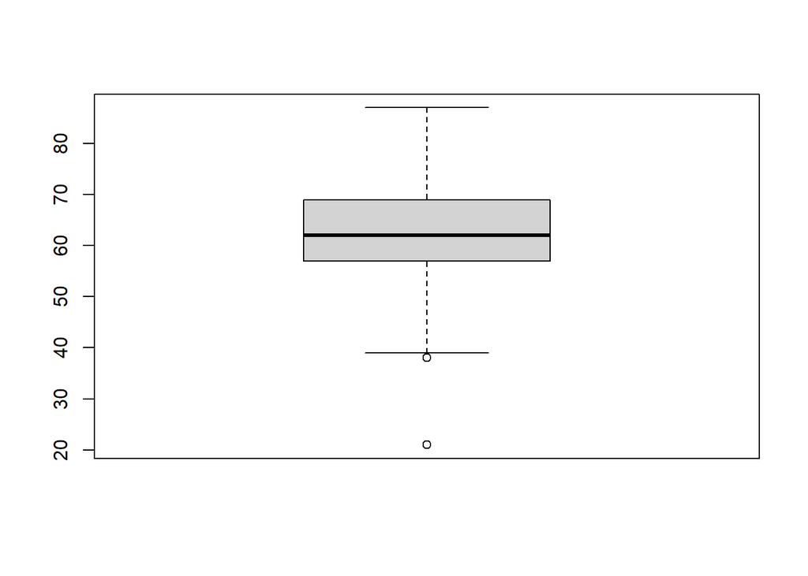

```r
boxplot(dane$AGE)
```

Jak widać w zmiennej AGE występują wartości odstające. Zmienne te zostaną usunięte.

```r
Q1 <- quantile(dane$AGE, probs = 0.25)
Q3 <- quantile(dane$AGE, probs = 0.75)
IQR <- Q3 - Q1
lower_bound <- Q1 - 1.5 * IQR
upper_bound <- Q3 + 1.5 * IQR

dane <- subset(dane, AGE > lower_bound & AGE < upper_bound)
```

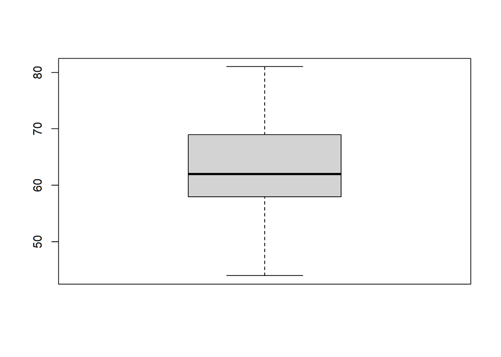

```r
boxplot(dane$AGE)
```

Brakujące wartości w zbiorze:

```r
sum(is.na(dane))
```

```
## [1] 0
```

W zbiorze nie występują żadne braki w danych. Następnym krokiem w przygotowaniu danych będzie zamiana zmiennych kategorycznych na zmienne ilościowe.

```r
str(dane)
```

```
## 'data.frame':    305 obs. of  16 variables:
##  $ GENDER               : Factor w/ 2 levels "F","M": 2 2 1 2 1 1 2 1 1 2 ...
##  $ AGE                  : int  69 74 59 63 63 75 52 51 68 53 ...
##  $ SMOKING              : Factor w/ 2 levels "1","2": 1 2 1 2 1 1 2 2 2 2 ...
##  $ YELLOW_FINGERS       : Factor w/ 2 levels "1","2": 2 1 1 2 2 2 1 2 1 2 ...
##  $ ANXIETY              : Factor w/ 2 levels "1","2": 2 1 1 2 1 1 1 2 2 2 ...
##  $ PEER_PRESSURE        : Factor w/ 2 levels "1","2": 1 1 2 1 1 1 1 2 1 2 ...
##  $ CHRONIC.DISEASE      : Factor w/ 2 levels "1","2": 1 2 1 1 1 2 1 1 1 2 ...
##  $ FATIGUE              : Factor w/ 2 levels "1","2": 2 2 2 1 1 2 2 2 2 1 ...
##  $ ALLERGY              : Factor w/ 2 levels "1","2": 1 2 1 1 1 2 1 2 1 2 ...
##  $ WHEEZING             : Factor w/ 2 levels "1","2": 2 1 2 1 2 2 2 1 1 1 ...
##  $ ALCOHOL.CONSUMING    : Factor w/ 2 levels "1","2": 2 1 1 2 1 1 2 1 1 2 ...
##  $ COUGHING             : Factor w/ 2 levels "1","2": 2 1 2 1 2 2 2 1 1 1 ...
##  $ SHORTNESS.OF.BREATH  : Factor w/ 2 levels "1","2": 2 2 2 1 2 2 2 2 1 1 ...
##  $ SWALLOWING.DIFFICULTY: Factor w/ 2 levels "1","2": 2 2 1 2 1 1 1 2 1 2 ...
##  $ CHEST.PAIN           : Factor w/ 2 levels "1","2": 2 2 2 2 1 1 2 1 1 2 ...
##  $ LUNG_CANCER          : Factor w/ 2 levels "NO","YES": 2 2 1 1 1 2 2 2 1 2 ...
```

Zmienna GENDER jest zmienną kategoryczną przyjmującą wartości “F” oraz “M”, zmienna ta zostanie zamieniona na zmienną zero-jedynkową. Zmienne przyjmujące wartośći “1” oraz “2” zostaną zamienione również na zmienne zero-jedynkowe. Zmienna wynikowa LUNG_CANCER zosatnie zapisana w postaci binarnej, gdzie 0 oznacza osobę nie chorującą na raka, a 1 osobę chorującą na raka.

```r
levels(dane$GENDER) <- c("0", "1")
dane$GENDER <- as.numeric(as.character(dane$GENDER))

dane$AGE <- as.numeric(as.character(dane$AGE))

for (i in 3:15){
  levels(dane[,i]) <- c("0", "1")
    dane[,i] <- as.numeric(as.character(dane[,i]))
}

levels(dane$LUNG_CANCER) <- c("0", "1")
```

```r
set.seed(9)
index  <- sample(nrow(dane), 230, replace = F)
uczacy <- dane[index,]
testowy <- dane[-index,]
```

Po wykonaniu podziału na zbiór uczący oraz testowy należy zestandaryzować zmienną AGE.

```r
uczacy$AGE <- scale(uczacy$AGE)
testowy$AGE <- scale(testowy$AGE)
```

### Metoda k najbliższych sąsiadów (KNN)

Na początku zostanie wybrana najlepsza ilość sąsiadów, w tym celu zosatnie przeanalizowany wykres maksymalizujący dokładność na zbiorze testowym w zależności od wielkości k.

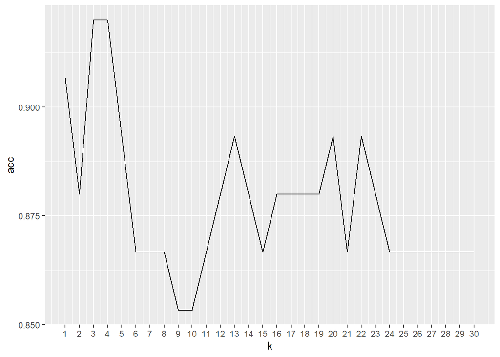

```r
library(ggplot2)
library(class)
acc = c()
for(i in 1:30){
  knn.model <- knn(train = uczacy[, -16],
                   test = testowy[, -16],
                   cl = uczacy[, 16],
                   k = i)

  t = table(knn.model, testowy[,16])
  acc[i] = (t[1,1]+t[2,2])/sum(t)
}

ggplot(data.frame(acc, k = 1:30))+
  geom_line(aes(x=k, y=acc))+
  scale_x_continuous(breaks=1:30)
```

Jak widać na powyższym wykresie największą dokładność na zbiorze testowym otrzymamy dla k równego 3 lub 4. Najsłabiej w zestawienu mają się wartości k=9 oraz k=10, które pozwolą na otrzymanie dokładności na poziomie ponad 85% co jest dobrym wynikiem lecz znacznie słabszym w porównaniu do wartości 3 oraz 4. W natępnej części zostaną stworzone dwa modele KNN dla k=3 oraz k=4.

**Klasyfikacja KNN dla k = 3**

```r
knn.uczacy3 <- knn(train = uczacy[,-16],
                  test = uczacy[,-16],
                  cl = uczacy[,16],
                  k = 3)

# Macierz błędu dla zbioru uczącego:

t1_3 <- table(knn.uczacy3, uczacy$LUNG_CANCER)

# Macierz błędu na zbiorze testowym:
knn.testowy3 <- knn(train = uczacy[, -16],
                   test = testowy[, -16],
                   cl = uczacy[, 16],
                   k = 3)
t2_3 <- table(knn.testowy3, testowy$LUNG_CANCER)
```

**Klasyfikacja KNN dla k = 4**

```r
knn.uczacy4 <- knn(train = uczacy[,-16],
                  test = uczacy[,-16],
                  cl = uczacy[,16],
                  k = 4)

# Macierz błędu dla zbioru uczącego:
t1_4 <- table(knn.uczacy4, uczacy$LUNG_CANCER)

# Macierz błędu na zbiorze testowym:
knn.testowy4 <- knn(train = uczacy[, -16],
                   test = testowy[, -16],
                   cl = uczacy[, 16],
                   k = 4)
t2_4 <- table(knn.testowy4, testowy$LUNG_CANCER)
```

##### **Porównanie modeli KNN dla k równego 3 oraz 4:**

Za pomocą stworzonych macierzy błędu dla każdego z modeli, jesteśmy w stanie obliczyć parametry takie jak:

- **Dokładność** - stosunek liczby prawidłowo sklasyfikowanych próbek do całkowitej liczby próbek
- **Czułość** - stosunek liczby prawidłowo sklasyfikowanych pozytywnych próbek do liczby rzeczywistych pozytywnych próbek
- **Specyficzność** - stosunek liczby prawidłowo sklasyfikowanych negatywnych próbek do liczby rzeczywistych negatywnych próbek

Macierz błędu dla zbioru uczącego:

```r
t1_3
```

```
##
## knn.uczacy3   0   1
##           0  19   5
##           1   8 198
```

```r
t1_4
```

```
##
## knn.uczacy4   0   1
##           0  15   6
##           1  12 197
```

Dokładność na zbiorze uczącym:

```r
(t1_3[1,1] + t1_3[2,2])/sum(t1_3)
```

```
## [1] 0.943
```

```r
(t1_4[1,1] + t1_4[2,2])/sum(t1_4)
```

```
## [1] 0.922
```

Czułość na zbiorze uczącym:

```r
t1_3[1,1]/(t1_3[1,1] + t1_3[1,2])
```

```
## [1] 0.792
```

```r
t1_4[1,1]/(t1_4[1,1] + t1_4[1,2])
```

```
## [1] 0.714
```

Specyficzność na zbiorze uczącym:

```r
t1_3[2,2]/(t1_3[2,2] + t1_3[1,2])
```

```
## [1] 0.975
```

```r
t1_4[2,2]/(t1_4[2,2] + t1_4[1,2])
```

```
## [1] 0.97
```

Macierz błędu na zbiorze testowym:

```r
t2_3
```

```
##
## knn.testowy3  0  1
##            0  5  1
##            1  5 64
```

```r
t2_4
```

```
##
## knn.testowy4  0  1
##            0  5  1
##            1  5 64
```

Dokładność na zbiorze testowym:

```r
(t2_3[1,1] + t2_3[2,2])/sum(t2_3)
```

```
## [1] 0.92
```

```r
(t2_4[1,1] + t2_4[2,2])/sum(t2_4)
```

```
## [1] 0.92
```

Czułość na zbiorze testowym:

```r
t2_3[1,1]/(t2_3[1,1] + t2_3[1,2])
```

```
## [1] 0.833
```

```r
t2_4[1,1]/(t2_4[1,1] + t2_4[1,2])
```

```
## [1] 0.833
```

Specyficzność na zbiorze testowym:

```r
t2_3[2,2]/(t2_3[2,2] + t2_3[1,2])
```

```
## [1] 0.985
```

```r
t2_4[2,2]/(t2_4[2,2] + t2_4[1,2])
```

```
## [1] 0.985
```

Dokładość jest wykorzystywana do oceny ogólnej modelu, w modelach stworzonych na zbiorze uczącym nieznacznie wyższą dokładność otrzymujemy dla k=3 równą 0,943. Czułość mówi nam jak dobrze model rozpoznaje pozytywne przypadki, w badanym zbiorze uczącym wartość tego parametru jest większa dla modelu z 3 sąsiadami i wynosi ona 0,792 gdzie dla modelu z 4 sąsiadami jest równa 0,714. Specyficzność jest parametrem mówiącym jak dobrze model rozpoznaje negatywne przypadki. Model stworzony na zbiorze uczącym dla k=3 nieznacznie lepiej rozpoznaje negatywne przypadki w przeciwieństwie do modelu dla k=4.

W modelach stworzonych na zbiorze testowym otrzymana została taka sama macierz błędu dla 3 oraz k sąsiadów. Wszystkie trzy parametry (dokładność, czułość oraz specyficzność) są dokładnie takie same dla każdego z parametrów

Obydwa modele posiadają bardzo podobne parametry na zbiorach testowych oraz uczących, do dalszej częsci projektu zostanie wykorzystany model z 3 sąsiadami.

### **Ważona metoda k najbliższych sąsiadów (KKNN)**

Ważona metoda k-NN polega na przypisywaniu nowych próbek do klasy, która jest najczęściej reprezentowana przez ich k najbliższych sąsiadów w zbiorze treningowym, przy czym każdy z tych sąsiadów ma przypisaną wagę. Waga ta może być ustalana na podstawie odległości między próbką, a sąsiadem. Waga jest używana do przeważenia głosów podczas przypisywania próbki do klasy.

Wybór liczby sąsiadów:

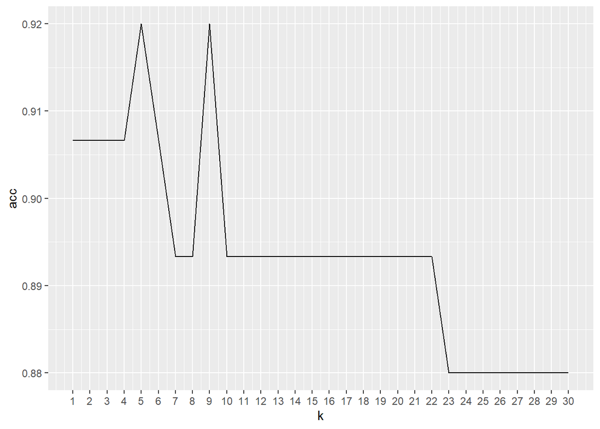

```r
library(kknn)

acc = c()
for(i in 1:30){
  kknn.testowy <- kknn(formula = uczacy[, 16]~.,
                    train = uczacy[, -16],
                    test = testowy[, -16],
                    k = i)
  kknn.testowy.wyniki <- fitted(kknn.testowy)
  t = table(kknn.testowy.wyniki, testowy[,16])
  acc[i] = (t[1,1]+t[2,2])/sum(t)
}

ggplot(data.frame(acc, k = 1:30))+
  geom_line(aes(x=k, y=acc))+
  scale_x_continuous(breaks=1:30)
```

**Klasyfikacja KKNN dla k=5**

```r
library(kknn)
kknn.uczacy5 <- kknn(formula = uczacy[, 16]~.,
                    train = uczacy[, -16],
                    test = uczacy[, -16],
                    k = 5)

# Prognoza wartości Y:
kknn.uczacy.wyniki5 <- fitted(kknn.uczacy5)

# Macierz błędu dla zbioru uczącego:
t3_5 <- table(kknn.uczacy.wyniki5, uczacy$LUNG_CANCER)

# Macierz błędu na zbiorze testowym:
kknn.testowy5 <- kknn(formula = uczacy[, 16]~.,
                    train = uczacy[, -16],
                    test = testowy[, -16],
                    k = 5)

kknn.testowy.wyniki5 <- fitted(kknn.testowy5)

t4_5 <- table(kknn.testowy.wyniki5, testowy$LUNG_CANCER)
```

**Klasyfikacja KKNN dla k =9**

```r
library(kknn)
kknn.uczacy9 <- kknn(formula = uczacy[, 16]~.,
                    train = uczacy[, -16],
                    test = uczacy[, -16],
                    k = 9)

# Prognoza wartości Y:
kknn.uczacy.wyniki9 <- fitted(kknn.uczacy9)

# Macierz błędu dla zbioru uczącego:
t3_9 <- table(kknn.uczacy.wyniki9, uczacy$LUNG_CANCER)

# Macierz błędu na zbiorze testowym:
kknn.testowy9 <- kknn(formula = uczacy[, 16]~.,
                    train = uczacy[, -16],
                    test = testowy[, -16],
                    k = 9)

kknn.testowy.wyniki9 <- fitted(kknn.testowy9)

t4_9 <- table(kknn.testowy.wyniki9, testowy$LUNG_CANCER)
```

##### **Porównanie modeli KKNN dla k równego 5 oraz 9:**

Macierz błędu dla zbioru uczącego:

```r
t3_5
```

```
##
## kknn.uczacy.wyniki5   0   1
##                   0  24   3
##                   1   3 200
```

```r
t3_9
```

```
##
## kknn.uczacy.wyniki9   0   1
##                   0  20   4
##                   1   7 199
```

Dokładność na zbiorze uczącym:

```r
(t3_5[1,1] + t3_5[2,2])/sum(t3_5)
```

```
## [1] 0.974
```

```r
(t3_9[1,1] + t3_9[2,2])/sum(t3_9)
```

```
## [1] 0.952
```

Czułość na zbiorze uczącym:

```r
t3_5[1,1]/(t3_5[1,1] + t3_5[1,2])
```

```
## [1] 0.889
```

```r
t3_9[1,1]/(t3_9[1,1] + t3_9[1,2])
```

```
## [1] 0.833
```

Specyficzność na zbiorze uczącym:

```r
t3_5[2,2]/(t3_5[2,2] + t3_5[1,2])
```

```
## [1] 0.985
```

```r
t3_9[2,2]/(t3_9[2,2] + t3_9[1,2])
```

```
## [1] 0.98
```

Macierz błędu na zbiorze testowym:

```r
t4_5
```

```
##
## kknn.testowy.wyniki5  0  1
##                    0  7  3
##                    1  3 62
```

```r
t4_9
```

```
##
## kknn.testowy.wyniki9  0  1
##                    0  5  1
##                    1  5 64
```

Dokładność na zbiorze testowym:

```r
(t4_5[1,1] + t4_5[2,2])/sum(t4_5)
```

```
## [1] 0.92
```

```r
(t4_9[1,1] + t4_9[2,2])/sum(t4_9)
```

```
## [1] 0.92
```

Czułość na zbiorze testowym:

```r
t4_5[1,1]/(t4_5[1,1] + t4_5[1,2])
```

```
## [1] 0.7
```

```r
t4_9[1,1]/(t4_9[1,1] + t4_9[1,2])
```

```
## [1] 0.833
```

Specyficzność na zbiorze testowym:

```r
t4_5[2,2]/(t4_5[2,2] + t4_5[1,2])
```

```
## [1] 0.954
```

```r
t4_9[2,2]/(t4_9[2,2] + t4_9[1,2])
```

```
## [1] 0.985
```

Analizując parametry otrzymane dla zbiorów uczących model z 5 sąsiadami jest nieznacznie lepszy w porównaiu do modelu z 9 sąsiadami. Przeciwna sytuacja ma miejsce w zbiorze testowym, gdzie obydwa modele mają taką samą dokładność równą 0,92, lecz model z k=9 lepiej rozpoznaje pozytywne jak i negatywne przypadki. W takim przypadku lepszym modelem wydaję się model z większą liczbą sąsiadów, ponieważ jest on bardziej skoncentrowany na generalizacji danych, a nie tylko na dopaswaniu danych treningowych.

### **Podsumowanie**

Do porównia metod KNN oraz KKNN zostanie wykorzystany parametr dokładności na zbiorach uczącym i testowym oraz krzywa ROC, która przedstawia zależność między False Positive Rate (FPR) a True Positive Rate (TPR) dla różnych progów decyzyjnych. Pole powierzchni pod krzywą (AUC) mówi w jakim stopni klasyfikator odróżnia przypadki pozytywne od negatywnych, gdzie wartość 1 oznacza perfekcyjne odróznienie, a wartość 0 bardzo złe.

#### **Zestawienie wartości dokładności na zbiorach uczącym i testowym dla wykonanych metod:**

| metoda | ACC_uczacy | ACC_testowy |
| --- | --- | --- |
| KNN | 0.943 | 0.92 |
| KKNN | 0.952 | 0.92 |

#### **Krzywa ROC**

**Metoda KNN**

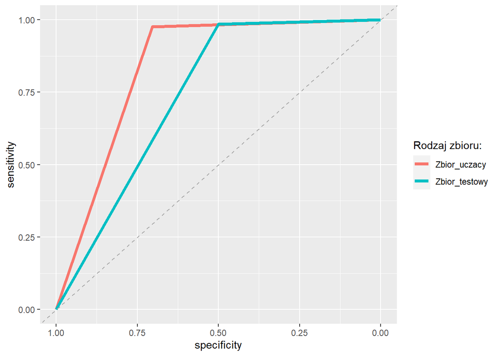

```
## Area under the curve: 0.84
```

```
## Area under the curve: 0.742
```

**Metoda KKNN**

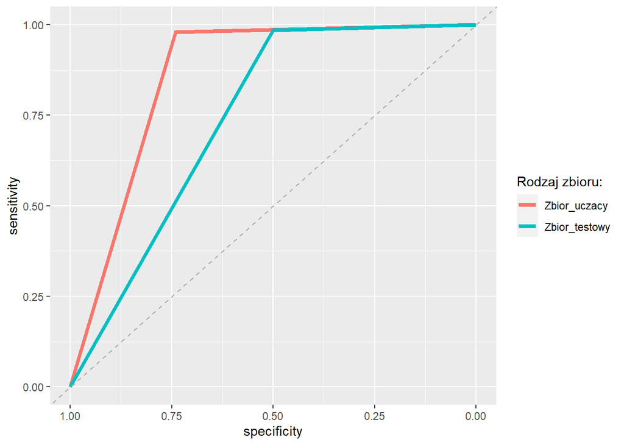

```
## Area under the curve: 0.861
```

```
## Area under the curve: 0.742
```